# Assignment: Prediction Assignment Writeup

# Background

Using devices such as Jawbone Up, Nike FuelBand, and Fitbit it is now possible to collect a large amount of data about personal activity relatively inexpensively. These type of devices are part of the quantified self movement – a group of enthusiasts who take measurements about themselves regularly to improve their health, to find patterns in their behavior, or because they are tech geeks. One thing that people regularly do is quantify how much of a particular activity they do, but they rarely quantify how well they do it. In this project, your goal will be to use data from accelerometers on the belt, forearm, arm, and dumbell of 6 participants. They were asked to perform barbell lifts correctly and incorrectly in 5 different ways. More information is available from the website here: http://groupware.les.inf.puc-rio.br/har (see the section on the Weight Lifting Exercise Dataset).

# Data

The training data for this project are available here:

https://d396qusza40orc.cloudfront.net/predmachlearn/pml-training.csv

The test data are available here:

https://d396qusza40orc.cloudfront.net/predmachlearn/pml-testing.csv

The data for this project come from this source: http://groupware.les.inf.puc-rio.br/har . If you use the document you create for this class for any purpose please cite them as they have been very generous in allowing their data to be used for this kind of assignment.

# Goal

The goal of your project is to predict the manner in which they did the exercise. This is the “classe” variable in the training set. You may use any of the other variables to predict with. You should create a report describing how you built your model, how you used cross validation, what you think the expected out of sample error is, and why you made the choices you did. You will also use your prediction model to predict 20 different test cases.

# Loading Data

```r
library("data.table")
# training data
url_train <- "https://d396qusza40orc.cloudfront.net/predmachlearn/pml-training.csv"

training <- fread(url_train, na.strings = c("#DIV/0", "", "NA"), stringsAsFactors = TRUE, showProgress = FALSE)

# testing data
url_test <- "https://d396qusza40orc.cloudfront.net/predmachlearn/pml-testing.csv"

testing <- fread(url_test, na.strings = c("#DIV/0", "", "NA"), stringsAsFactors = TRUE, showProgress = FALSE)
```

# Data Preprocessing

```r
head(training)
```

| V1 | user_name | raw_timestamp_part_1 | raw_timestamp_part_2 | cvtd_timestamp | new_window | num_window | roll_belt | pitch_belt | yaw_belt | total_accel_belt | kurtosis_roll_belt | kurtosis_picth_belt | kurtosis_yaw_belt | skewness_roll_belt | skewness_roll_belt.1 | skewness_yaw_belt | max_roll_belt | max_picth_belt | max_yaw_belt | min_roll_belt | min_pitch_belt | min_yaw_belt | amplitude_roll_belt | amplitude_pitch_belt | amplitude_yaw_belt | var_total_accel_belt | avg_roll_belt | stddev_roll_belt | var_roll_belt | … |
| --- | --- | --- | --- | --- | --- | --- | --- | --- | --- | --- | --- | --- | --- | --- | --- | --- | --- | --- | --- | --- | --- | --- | --- | --- | --- | --- | --- | --- | --- | --- |
| 1 | carlitos | 1323084231 | 788290 | 05/12/2011 11:23 | no | 11 | 1.41 | 8.07 | -94.4 | 3 | NA | NA | NA | NA | NA | NA | NA | NA | NA | NA | NA | NA | NA | NA | NA | NA | NA | NA | NA | … |
| 2 | carlitos | 1323084231 | 808298 | 05/12/2011 11:23 | no | 11 | 1.41 | 8.07 | -94.4 | 3 | NA | NA | NA | NA | NA | NA | NA | NA | NA | NA | NA | NA | NA | NA | NA | NA | NA | NA | NA | … |
| 3 | carlitos | 1323084231 | 820366 | 05/12/2011 11:23 | no | 11 | 1.42 | 8.07 | -94.4 | 3 | NA | NA | NA | NA | NA | NA | NA | NA | NA | NA | NA | NA | NA | NA | NA | NA | NA | NA | NA | … |
| 4 | carlitos | 1323084232 | 120339 | 05/12/2011 11:23 | no | 12 | 1.48 | 8.05 | -94.4 | 3 | NA | NA | NA | NA | NA | NA | NA | NA | NA | NA | NA | NA | NA | NA | NA | NA | NA | NA | NA | … |
| 5 | carlitos | 1323084232 | 196328 | 05/12/2011 11:23 | no | 12 | 1.48 | 8.07 | -94.4 | 3 | NA | NA | NA | NA | NA | NA | NA | NA | NA | NA | NA | NA | NA | NA | NA | NA | NA | NA | NA | … |
| 6 | carlitos | 1323084232 | 304277 | 05/12/2011 11:23 | no | 12 | 1.45 | 8.06 | -94.4 | 3 | NA | NA | NA | NA | NA | NA | NA | NA | NA | NA | NA | NA | NA | NA | NA | NA | NA | NA | NA | … |

```r
training <- training[, -c(1:7)]
testing <- testing[, -c(1:7)]
```

```r
rbind(training = dim(training), testing = dim(testing))
```

```
          [,1] [,2]
training 19622  153
testing     20  153
```

```r
library("purrr")
# Function to remove columns with NAs
na_remove_col <- function(data, threshold) {
    data %>%
    discard(~ sum(is.na(.x)) / length(.x) * 100 > threshold)
}

clean_train <- na_remove_col(training, 70)

clean_test <- na_remove_col(testing, 70)

rbind(training = dim(clean_train), testing = dim(clean_test))
```

```
          [,1] [,2]
training 19622   53
testing     20   53
```

# Data Partition

```r
library("caret")
inTrain <- createDataPartition(clean_train$classe, p=0.7, list=FALSE)

train <- clean_train[inTrain, ]
test <- clean_train[-inTrain, ]
```

# Exploratory Data Analysis

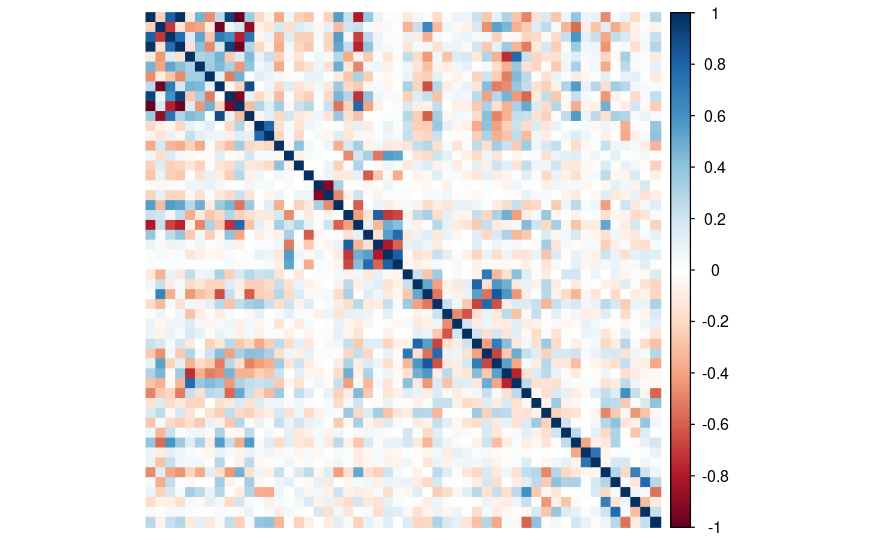

```r
library("corrplot")
library("dplyr")
corr_data <- select_if(train, is.numeric)
corrplot(cor(corr_data), method = "color", tl.pos = "n", insig = "blank")
```

# Prediction

```r
library("parallel")
library("doParallel")
cluster <- makeCluster(detectCores() - 1)
registerDoParallel(cluster)
```

```r
set.seed(2021)

fitControl <- trainControl(method = "cv",
                           number = 7,
                           allowParallel = TRUE)

rf.fit <- train(classe ~ .,
                method = "rf",
                data = train,
                trControl = fitControl)

# Stop cluster
stopCluster(cluster)
registerDoSEQ()
```

## Model Performance

```r
model.rf = rf.fit
```

```r
model.rf$finalModel
```

```
Call:
 randomForest(x = x, y = y, mtry = param$mtry)
               Type of random forest: classification
                     Number of trees: 500
No. of variables tried at each split: 2

        OOB estimate of  error rate: 0.78%
Confusion matrix:
     A    B    C    D    E  class.error
A 3904    2    0    0    0 0.0005120328
B   15 2635    8    0    0 0.0086531226
C    0   23 2369    4    0 0.0112687813
D    0    0   43 2206    3 0.0204262877
E    0    1    1    7 2516 0.0035643564
```

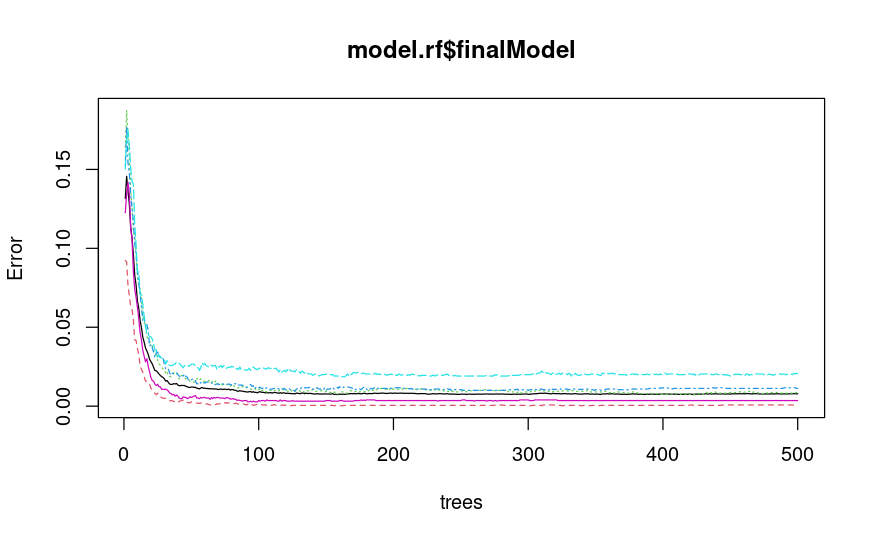

```r
plot(model.rf$finalModel)
```

## Variable Importance

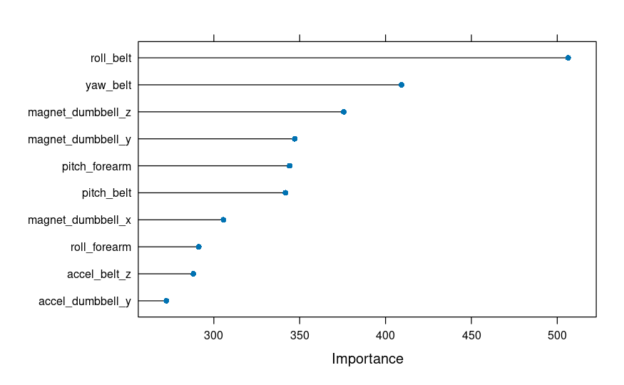

```r
importance <- varImp(model.rf, scale = FALSE)
plot(importance, top=10)
```

## Prediction On Test Set

```r
pred.rf <- predict(model.rf, test)
confM <- confusionMatrix(test$classe, pred.rf)
confM$table
```

```
          Reference
Prediction    A    B    C    D    E
         A 1672    0    1    0    1
         B    4 1134    1    0    0
         C    0    6 1019    1    0
         D    0    0   16  947    1
         E    0    0    0    0 1082
```

```r
confM$overall["Accuracy"]
```

```
 Accuracy
0.9947324
```

# Prediction On Validation Set

```r
final.pred.rf <- predict(model.rf, clean_test)
summary(final.pred.rf)
```

```
A B C D E
7 8 1 1 3
```

```r
final.pred.rf
```

```
 [1] B A B A A E D B A A B C B A E E A B B B
Levels: A B C D E
```